# PXD002801 Gygi lab mouse liver re-analysis

## Quality control and sanity check notebook

### performed by Phil Wilmarth, PSR Core OHSU

#### November 3, 2025

- Overview
- Data loading
- Removing plex effects with IRS
- TMM normalization and final clustering
- CV distributions
- Sample-to-sample scatter plots
- Summary

## Overview

> Chick, J.M., Munger, S.C., Simecek, P., Huttlin, E.L., Choi, K., Gatti, D.M., Raghupathy, N., Svenson, K.L., Churchill, G.A. and Gygi, S.P., 2016. Defining the consequences of genetic variation on a proteome-wide scale. Nature, 534(7608), pp.500-505.

This QC notebook will address these questions:

- Does internal reference scaling (IRS) (*Plubell 2017*) remove TMT plex "batch effects"?
- Do the samples cluster by biological group?
- Are normalization factors small and consistent?
- Are samples within groups similar to each other?

#### Sample Key:

| Channel | Plex1 | Plex2 | Plex3 | Plex4 |
| --- | --- | --- | --- | --- |
| 126c | AJ_F1 | AJ_F2 | AJ_M1 | AJ_M2 |
| 127n | NOD_M1 | NOD_M2 | NOD_F1 | NOD_F2 |
| 127c | C_F1 | C_F2 | C_M1 | C_M2 |
| 128n | P_M1 | P_M2 | P_F1 | P_F2 |
| 128c | NZO_F1 | NZO_F2 | NZO_M1 | NZO_M2 |
| 129n | WSB_M1 | WSB_M2 | WSB_F1 | WSB_F2 |
| 129c | B_F1 | B_F2 | B_M1 | B_M2 |
| 130n | 129_M1 | 129_M2 | 129_F1 | 129_F2 |
| 130c | B_M2 | NZO_M1 | C_F2 | AJ_F1 |
| 131n | 129_F2 | WSB_F1 | P_M2 | NOD_M1 |
| 131c | Pool | Pool | Pool | Pool |

This is a somewhat balanced study design, so the average intensities for each protein in each plex might work for IRS.

### References

> Wilmarth, P.A., Riviere, M.A. and David, L.L., 2009. Techniques for accurate protein identification in shotgun proteomic studies of human, mouse, bovine, and chicken lenses. Journal of ocular biology, diseases, and informatics, 2(4), pp.223-234.

> Plubell, D.L., Wilmarth, P.A., Zhao, Y., Fenton, A.M., Minnier, J., Reddy, A.P., Klimek, J., Yang, X., David, L.L. and Pamir, N., 2017. Extended multiplexing of tandem mass tags (TMT) labeling reveals age and high fat diet specific proteome changes in mouse epididymal adipose tissue. Molecular & Cellular Proteomics, 16(5), pp.873-890.

## This notebook examines quality control metrics

## Load the necessary R libraries

```r
# library imports
library(tidyverse)
library(scales)
library(limma)
library(edgeR)
library(psych)
```

## Define common functions for notebook use

```r
# ================== TMM normalization from DGEList object =====================
apply_tmm_factors <- function(y, color = NULL, plot = TRUE) {
    # computes the tmm normalized data from the DGEList object
        # y - DGEList object
        # returns a dataframe with normalized intensities

    # compute and print "Sample loading" normalization factors
    lib_facs <- mean(y$samples$lib.size) / y$samples$lib.size
    cat("\nLibrary size factors:\n",
        sprintf("%-5s -> %f\n", colnames(y$counts), lib_facs))

    # compute and print TMM normalization factors
    tmm_facs <- 1/y$samples$norm.factors
    cat("\nTrimmed mean of M-values (TMM) factors:\n",
        sprintf("%-5s -> %f\n", colnames(y$counts), tmm_facs))

    # compute and print the final correction factors
    norm_facs <- lib_facs * tmm_facs
    cat("\nCombined (lib size and TMM) normalization factors:\n",
        sprintf("%-5s -> %f\n", colnames(y$counts), norm_facs))

    # compute the normalized data as a new data frame
    tmt_tmm <- as.data.frame(sweep(y$counts, 2, norm_facs, FUN = "*"))
    colnames(tmt_tmm) <- str_c(colnames(y$counts), "_tmm")

    # visualize results and return data frame
    if(plot == TRUE) {
        boxplot(log10(tmt_tmm), col = color, notch = TRUE, main = "TMM Normalized data")
    }
    tmt_tmm
}

# ============== CV function ===================================================
CV <- function(df) {
    # Computes CVs of data frame rows
        # df - data frame,
        # returns vector of CVs (%)
    ave <- rowMeans(df)    # compute averages
    sd <- apply(df, 1, sd) # compute standard deviations
    cv <- 100 * sd / ave   # compute CVs in percent (last thing gets returned)
}

# =========== Boxplot with median label ========================================
labeled_boxplot <- function(df, ylim, title) {
    # Makes a box plot with the median value labeled
        # df - data frame with data to compute CVs of
        # ylim - upper limit for y-axis
        # title - plot title
    cv = CV(df)
    boxplot(cv, ylim = c(0, ylim), notch = TRUE, main = title)
    text(x = 0.65, y = boxplot.stats(cv)$stats[3],
         labels = round(boxplot.stats(cv)$stats[3], 1))
}

set_plot_dimensions <- function(width_choice, height_choice) {
    options(repr.plot.width=width_choice, repr.plot.height=height_choice)
}
```

## Load the IRS-normalized TMT intensity data

The input data for the notebook was prepped in Excel from the IRS script output. The protein table excludes decoys, contaminants, some major blood proteins, and any proteins not seen in all 4 plexes.

```r
# load the IRS-normalized data and check the table
data_irs <- read_tsv("quant_table.txt")

# save gene names for edgeR so we can double check that results line up
accessions <- data_irs$Accession

# see how many rows of data we have
length(accessions)
```

5806

### Collect channels by biological conditions

There are 8 mouse strains; mice sex will be ignored.

```r
# define the groups (after IRS)
AJ_ <- select(data_irs, starts_with("AJ_"))
NOD_ <- select(data_irs, starts_with("NOD_"))
C_ <- select(data_irs, starts_with("C_"))
P_ <- select(data_irs, starts_with("P_"))
NZO_ <- select(data_irs, starts_with("NZO_"))
WSB_ <- select(data_irs, starts_with("WSB_"))
B_ <- select(data_irs, starts_with("B_"))
S129_ <- select(data_irs, starts_with("129_"))
```

### Make the organized data frames

We will put the organized data into a new data frame, define some column indexes for each biological group, and set colors for plotting.

```r
# put groups together into a single data frame
tmt_irs <- bind_cols(AJ_, NOD_, C_, P_, NZO_, WSB_, B_, S129_)

head(tmt_irs)
```

A tibble: 6 × 40

| AJ_F1_1 <dbl> | AJ_F2_2 <dbl> | AJ_M1_3 <dbl> | AJ_M2_4 <dbl> | AJ_F1_4 <dbl> | NOD_M1_1 <dbl> | NOD_M2_2 <dbl> | NOD_F1_3 <dbl> | NOD_F2_4 <dbl> | NOD_M1_4 <dbl> | ⋯ | B_F1_1 <dbl> | B_M2_1 <dbl> | B_F2_2 <dbl> | B_M1_3 <dbl> | B_M2_4 <dbl> | 129_M1_1 <dbl> | 129_F2_1 <dbl> | 129_M2_2 <dbl> | 129_F1_3 <dbl> | 129_F2_4 <dbl> |
| --- | --- | --- | --- | --- | --- | --- | --- | --- | --- | --- | --- | --- | --- | --- | --- | --- | --- | --- | --- | --- |
| 863140391 | 884437112 | 797147303 | 863179286 | 859509948 | 812290214 | 1492420269 | 1165919474 | 2033787177 | 822630450 | ⋯ | 607121458 | 618085291 | 546503283 | 780147937 | 626579581 | 995227243 | 998000853 | 859714091 | 827463464 | 980668351 |
| 228701706 | 208470584 | 247124721 | 239197079 | 237378828 | 260058689 | 471927205 | 376305265 | 464771913 | 280766827 | ⋯ | 277643871 | 271119461 | 249668780 | 319334546 | 277096356 | 346410575 | 366472169 | 299591471 | 335894485 | 366896287 |
| 348457568 | 394595503 | 382469785 | 302139722 | 346895466 | 351235648 | 49817923 | 147336943 | 17382964 | 384283569 | ⋯ | 352222154 | 359079947 | 432863921 | 325400349 | 357375824 | 304847977 | 280358374 | 354989993 | 283409571 | 295769446 |
| 233339952 | 230208778 | 176752924 | 183360429 | 250804255 | 186185173 | 171058649 | 188818772 | 127208515 | 204921057 | ⋯ | 437683612 | 334454974 | 359549764 | 422214585 | 333104072 | 184628213 | 241269631 | 191012740 | 230076256 | 255174313 |
| 223894348 | 252371114 | 203502012 | 202694569 | 237128603 | 166560104 | 178203858 | 178615175 | 331722680 | 175833076 | ⋯ | 243716376 | 166397448 | 183406565 | 245563179 | 171207019 | 201003133 | 239019717 | 194996338 | 283455366 | 234603710 |
| 181819990 | 159509178 | 176004698 | 174357221 | 183157156 | 145151776 | 172105985 | 157276987 | 157442323 | 148334032 | ⋯ | 211052327 | 229206805 | 243971812 | 183767996 | 224385477 | 162199632 | 189354445 | 165765052 | 157874185 | 184134056 |

```r
# define which columns go with each group
AJ <- 1:5
NOD <- 6:10
C <- 11:15
P <- 16:20
NZO <- 21:25
WSB <- 26:30
B <- 31:35
S129 <- 36:40

# set some colors by group
colors_group = c(rep('dark red', 5), rep('red', 5), rep('dark blue', 5), rep('blue', 5),
                 rep('dark green', 5), rep('green', 5), rep('black', 5), rep('dark grey', 5))
```

We expect to see each of the 4 plexes cluster by plex before adjusting intensities with the IRS method. This experiment does not have as balanced samples per plex as the CC experiment did. The plex batch-like effect should be removed by the IRS method and the clustering after IRS should be by biological groups. If the biological group clustering cannot be recovered, the mock reference channel approach may not be appropriate for this data.

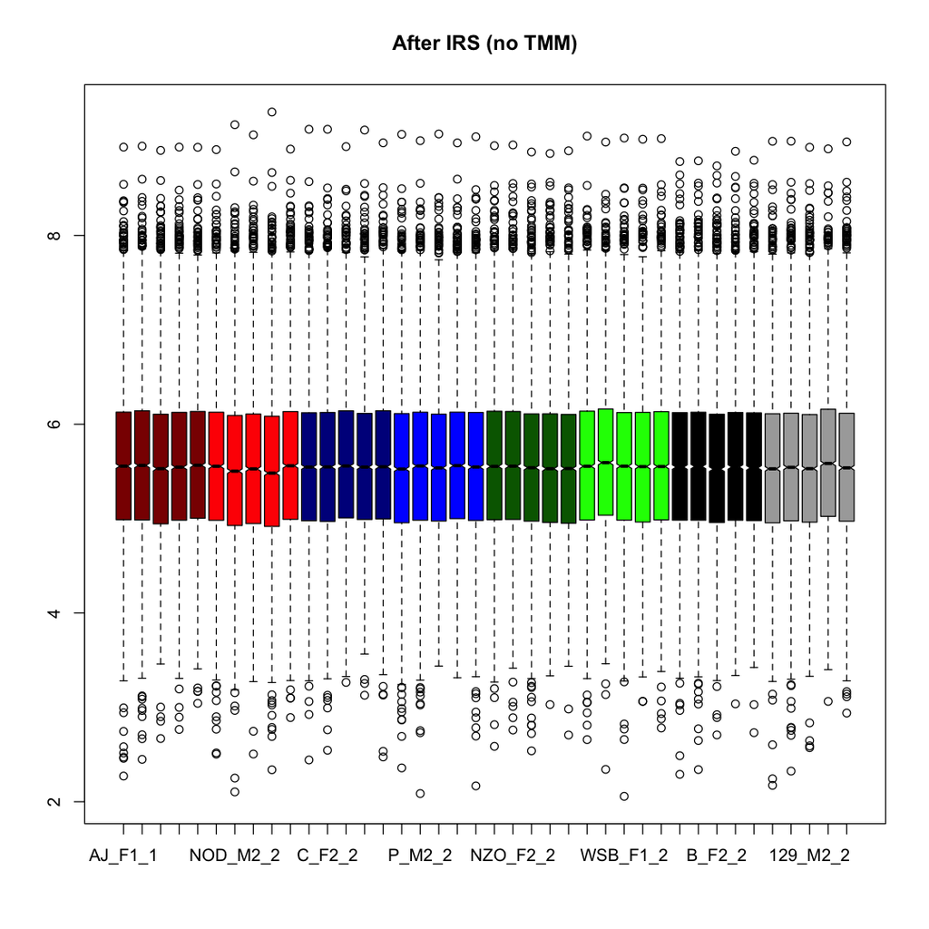

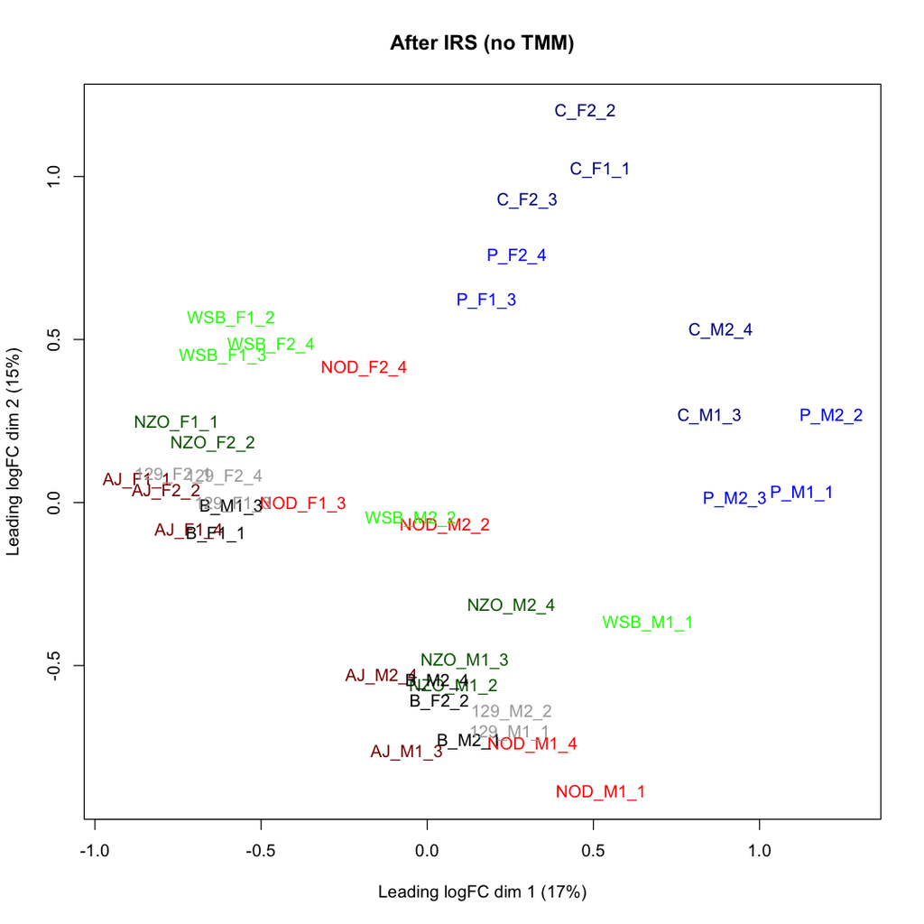

```r
# make default plot sizes a little bigger
set_plot_dimensions(9, 9)

# boxplots after IRS and before TMM
boxplot(log10(tmt_irs), col = colors_group, notch = TRUE, main = "After IRS (no TMM)")

# check clustering before IRS
plotMDS(log2(tmt_irs), main = "After IRS (no TMM)", col = colors_group)
```

## Run TMM normalization and check final clustering

We will load the data into edgeR data structures and call the `calcNormFactors` function to perform library size and the trimmed mean of M-values (TMM) normalization to correct for any sample composition differences. We will double check if the TMM normalization changed the clustering that we had above.

> Robinson, M.D. and Oshlack, A., 2010. A scaling normalization method for differential expression analysis of RNA-seq data. Genome biology, 11(3), p.R25.

We need to use the edgeR normalization factors to produce the TMM normalized data that the statistical testing will be working with. EdgeR uses the normalization factors in its statistical modeling but does not output the normalized intensities. We compute the normalized intensities with the `apply_tmm_factors function`.

```
Library size factors:
 AJ_F1_1 -> 0.995084
 AJ_F2_2 -> 0.994740
 AJ_M1_3 -> 0.991848
 AJ_M2_4 -> 1.000884
 AJ_F1_4 -> 1.006805
 NOD_M1_1 -> 1.004855
 NOD_M2_2 -> 1.010560
 NOD_F1_3 -> 1.000783
 NOD_F2_4 -> 0.996420
 NOD_M1_4 -> 1.000682
 C_F1_1 -> 0.996122
 C_F2_2 -> 0.994756
 C_M1_3 -> 1.003007
 C_F2_3 -> 1.006134
 C_M2_4 -> 0.994665
 P_M1_1 -> 1.001590
 P_M2_2 -> 0.997049
 P_F1_3 -> 1.001214
 P_M2_3 -> 1.000134
 P_F2_4 -> 1.004398
 NZO_F1_1 -> 0.995224
 NZO_F2_2 -> 0.997289
 NZO_M1_2 -> 1.003612
 NZO_M1_3 -> 0.992821
 NZO_M2_4 -> 0.999586
 WSB_M1_1 -> 1.002616
 WSB_M2_2 -> 1.000646
 WSB_F1_2 -> 0.996553
 WSB_F1_3 -> 1.003195
 WSB_F2_4 -> 0.994447
 B_F1_1 -> 1.000141
 B_M2_1 -> 1.003695
 B_F2_2 -> 0.996383
 B_M1_3 -> 0.998625
 B_M2_4 -> 0.999884
 129_M1_1 -> 1.005118
 129_F2_1 -> 0.998940
 129_M2_2 -> 1.005346
 129_F1_3 -> 1.004662
```

[output cut: 70 more lines]

```
 WSB_M1_1 -> 0.971862
 WSB_M2_2 -> 0.906156
 WSB_F1_2 -> 1.005272
 WSB_F1_3 -> 1.024135
 WSB_F2_4 -> 1.007476
 B_F1_1 -> 1.001115
 B_M2_1 -> 1.001790
 B_F2_2 -> 1.037615
 B_M1_3 -> 1.003471
 B_M2_4 -> 1.009455
 129_M1_1 -> 1.024664
 129_F2_1 -> 1.017267
 129_M2_2 -> 1.028134
 129_F1_3 -> 0.941071
 129_F2_4 -> 1.031696
```

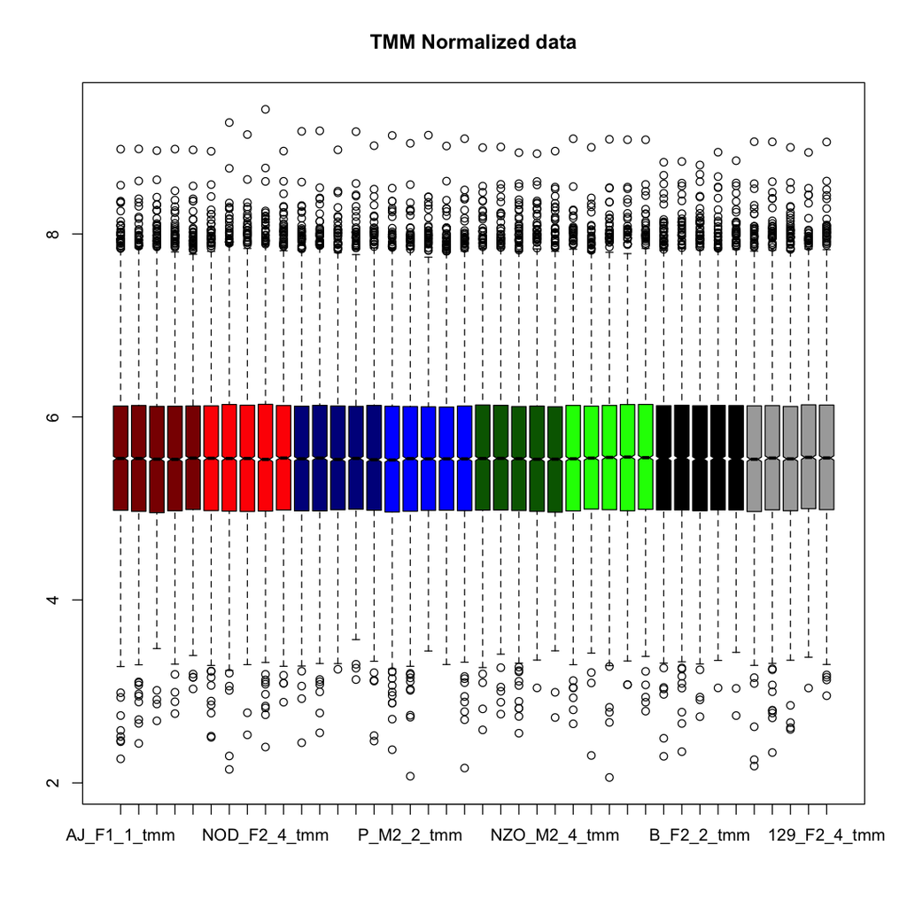

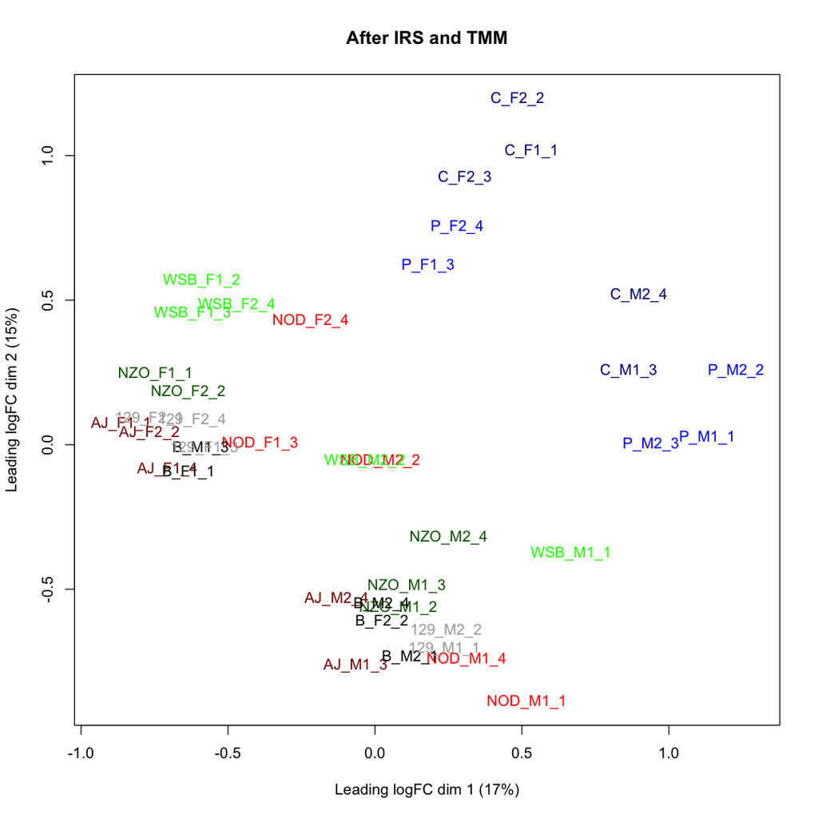

```r
# get the biological sample data into a DGEList object
group = c(rep("AJ", length(AJ)), rep("NOD", length(NOD)),
          rep("C", length(C)), rep("P", length(P)),
          rep("NZO", length(NZO)), rep("WSB", length(WSB)),
          rep("B", length(B)), rep("S129", length(S129)))

y <- DGEList(counts = tmt_irs, group = group, genes = accessions)

# run TMM normalization (also includes a library size factor)
y <- calcNormFactors(y)

# compute the TMM-normalized intensities
tmt_tmm <- apply_tmm_factors(y, color = colors_group)

# write the TMM-normalized intensities to file
write.table(cbind(accessions,tmt_tmm), "founder_IRS-plus-TMM.txt", sep = "\t",
            row.names = FALSE, na =  " ")

# check the clustering
plotMDS(y, col = colors_group, main = "After IRS and TMM")
```

### IRS and TMM seem to eliminate the plex effect

Boxplots and normalization factors suggest good sample-to-sample similarity after IRS and TMM adjustments. The clustering looks biological. We saw strong sex effects in the CC experiment, and we see that here. The pairs of samples from the same strain and same sex tend to cluster closely together.

## Check CV distributions

The distributions of Coefficients of Variation (CVs) are another way to get an idea of how individual proteins are behaving. This is an effective way to assess proper normalization in these experiments. We will compute CV distributions for each of the biological conditions.

```r
# put CVs in data frames to simplify plots and summaries
# we will skip the n=1 group (TOFPS)
cv_tmm <- data.frame(AJ = CV(tmt_tmm[AJ]), NOD = CV(tmt_tmm[NOD]),
                     C = CV(tmt_tmm[C]), P = CV(tmt_tmm[P]),
                     NZO = CV(tmt_tmm[NZO]), WSB = CV(tmt_tmm[WSB]),
                     B = CV(tmt_tmm[B]), S129 = CV(tmt_tmm[S129]))

medians <- apply(cv_tmm, 2, FUN = median)
print("Final median CVs by condition (%)")
round(medians, 2)
```

```
[1] "Final median CVs by condition (%)"
```

**AJ**

9.38

**NOD**

19.79

**C**

10.51

**P**

10.57

**NZO**

10.45

**WSB**

11.15

**B**

10.11

**S129**

10.35

#### Average median CV is 11.5%

The average median CV in this experiment is higher than we had for the CC experiment. That might be because male and female mice from each strain are being combined in the 8 founder strain groups. There are significant differences in the clusters of the male and female mice.

### Use ggplot to visualize the CV distributions

We will look at the final IRS plus TMM normalized data here.

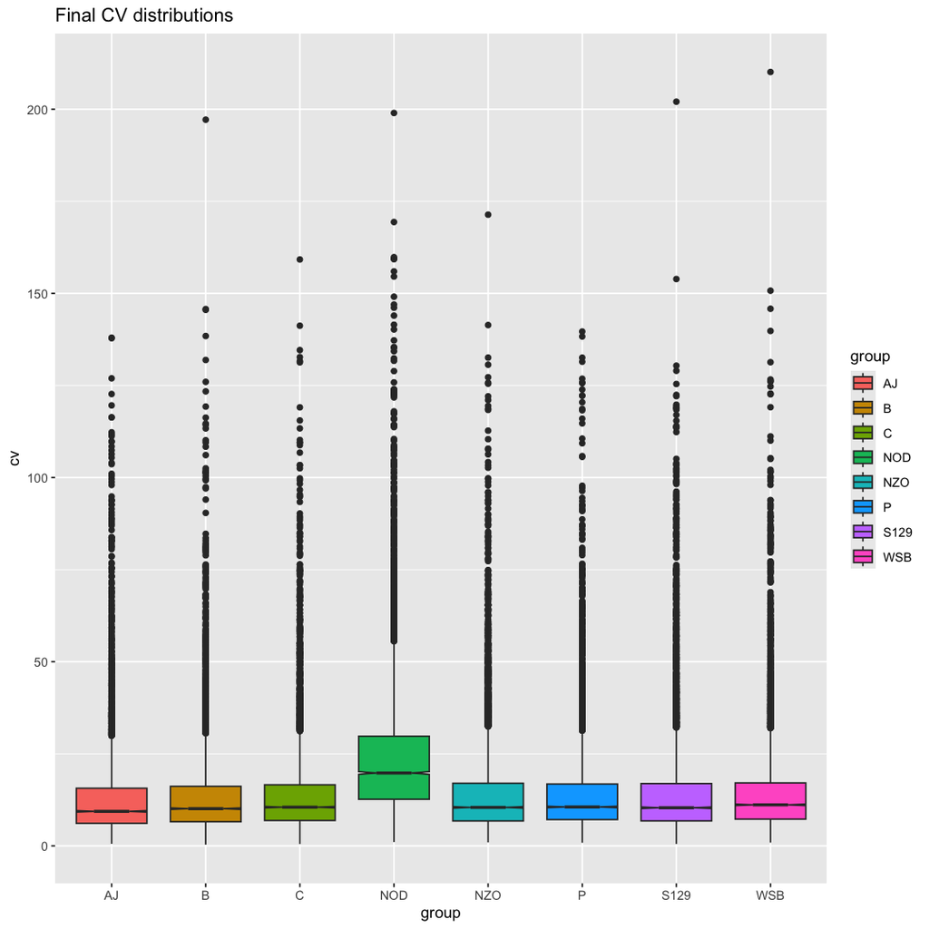

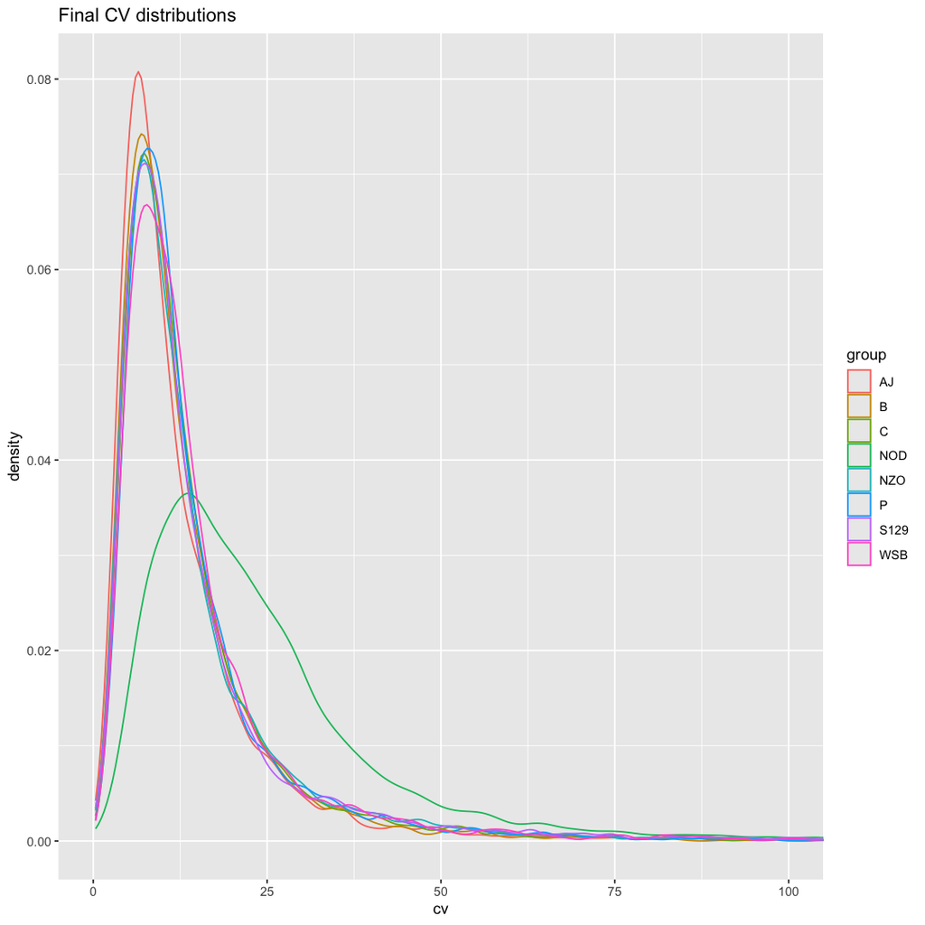

```r
# see what the CV distibutions look like
# need long form for ggplot
long_cv_tmm <- gather(cv_tmm, key = "group", value = "cv")

# traditional boxplots
ggplot(long_cv_tmm, aes(x = group, y = cv, fill = group)) +
  geom_boxplot(notch = TRUE) +
  ggtitle("Final CV distributions")

# density plots
ggplot(long_cv_tmm, aes(x = cv, color = group)) +
  geom_density() +
  coord_cartesian(xlim = c(0, 100)) +
  ggtitle("Final CV distributions")
```

#### The NOD strain stands out

The NOD strain has larger CVs than the other 7 strains.

## Compare samples within each biological condition

We can also look at each biological condition with a multi-panel scatter plot grid and see how similar the replicates are to each other. We can look at the intensities after IRS with TMM (final data). Since the male and female samples have been combined into the eight groups, each scatter plot grid will have tighter scatter plots for male samples compared to male samples (or female to female) and more scatter between sexes.

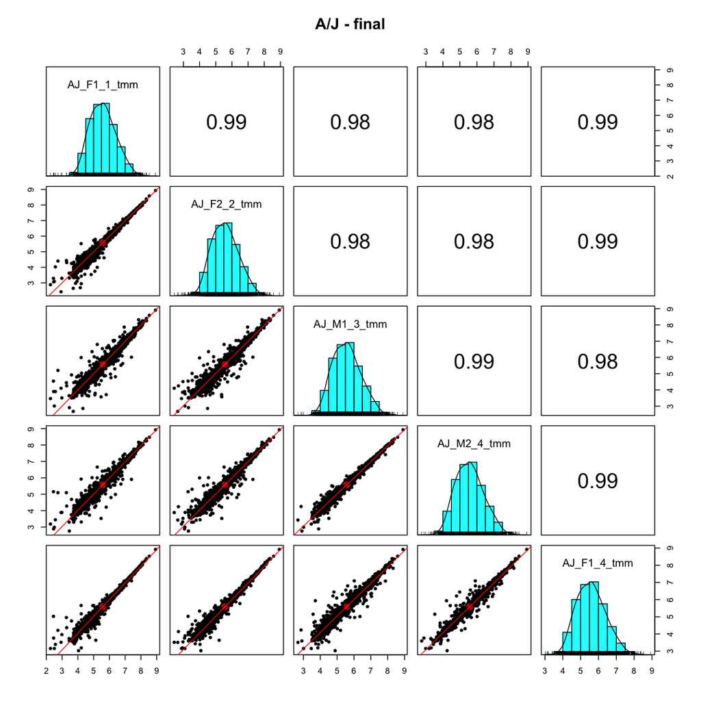

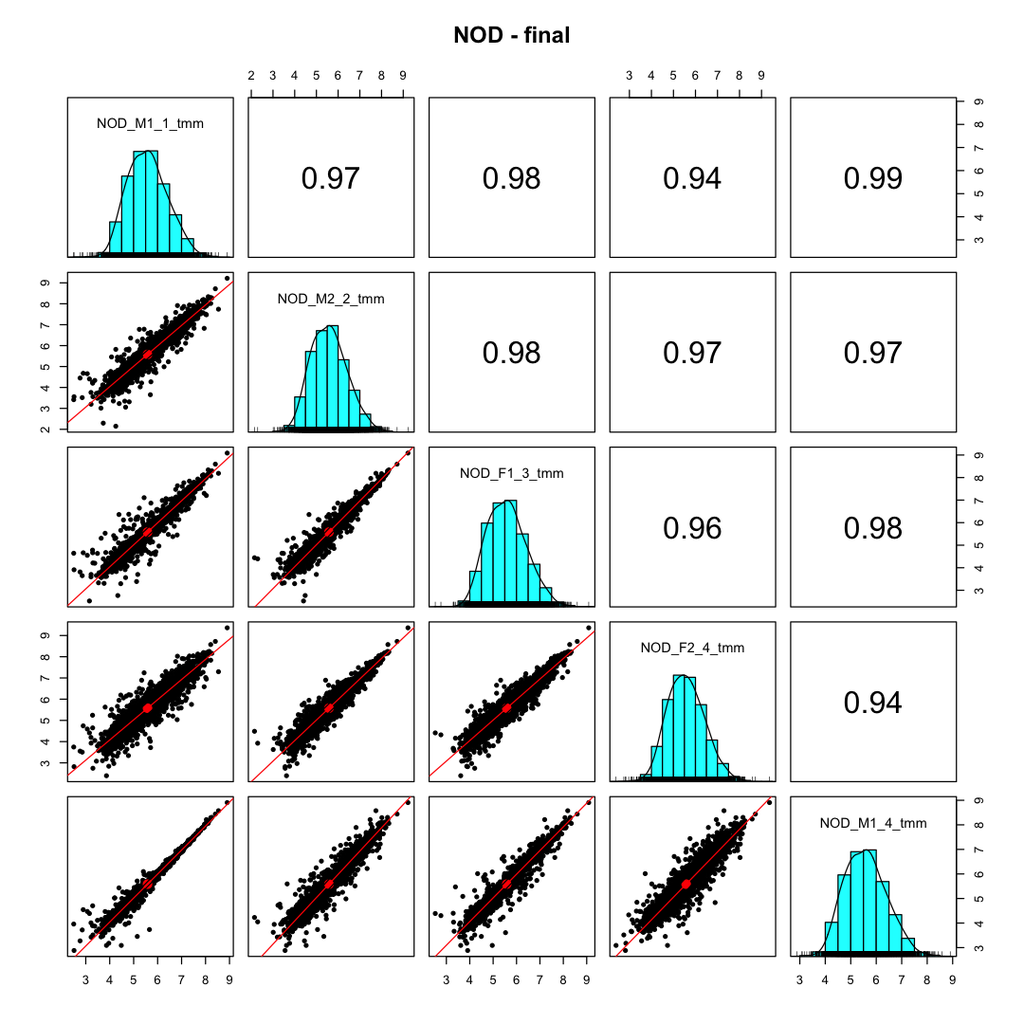

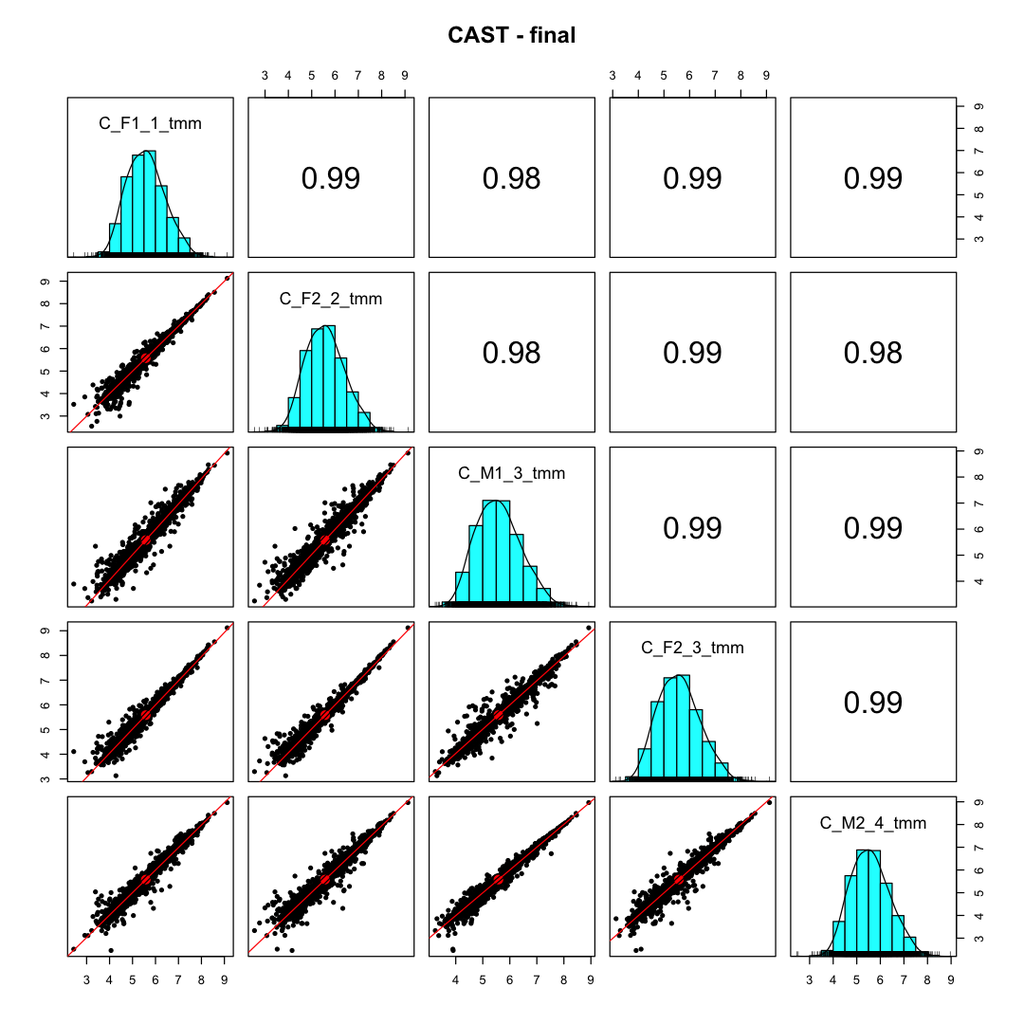

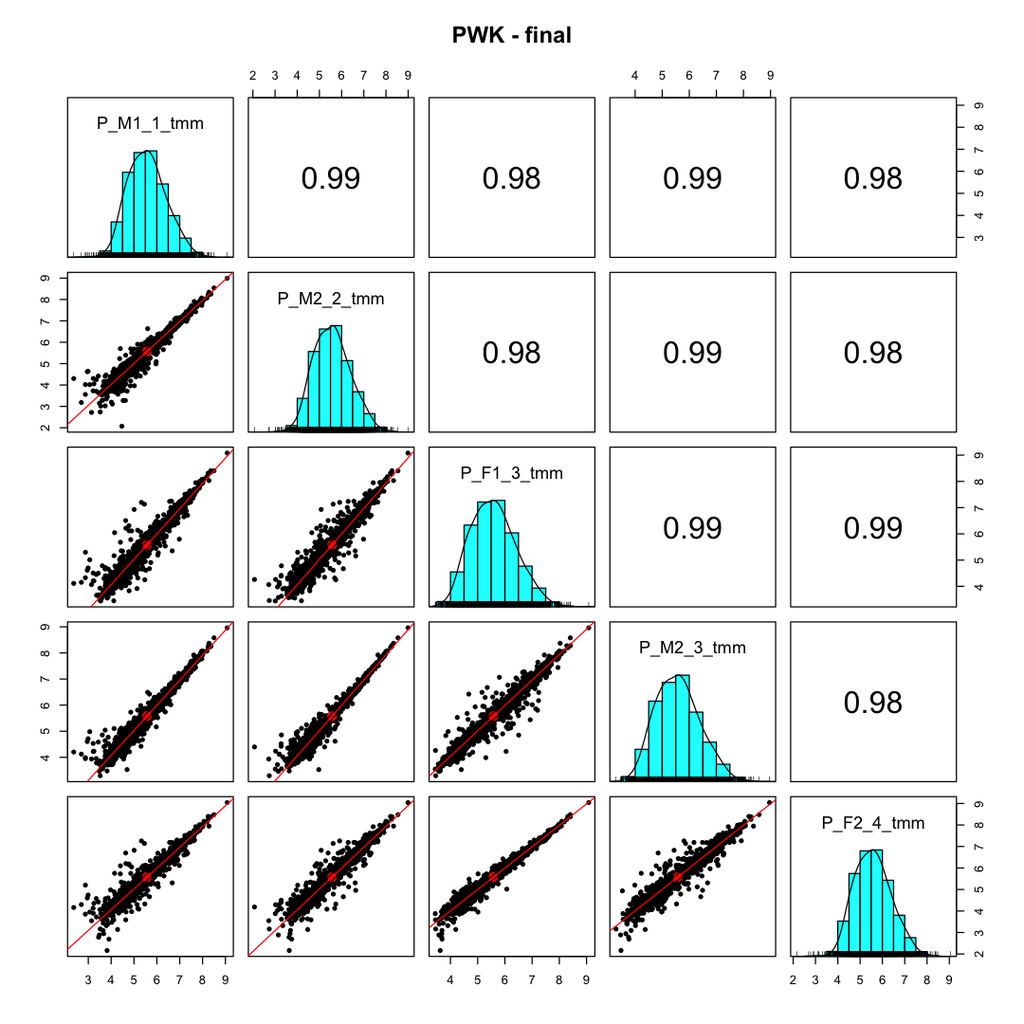

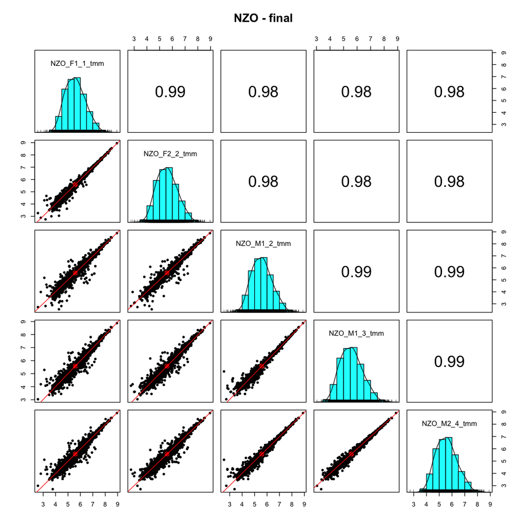

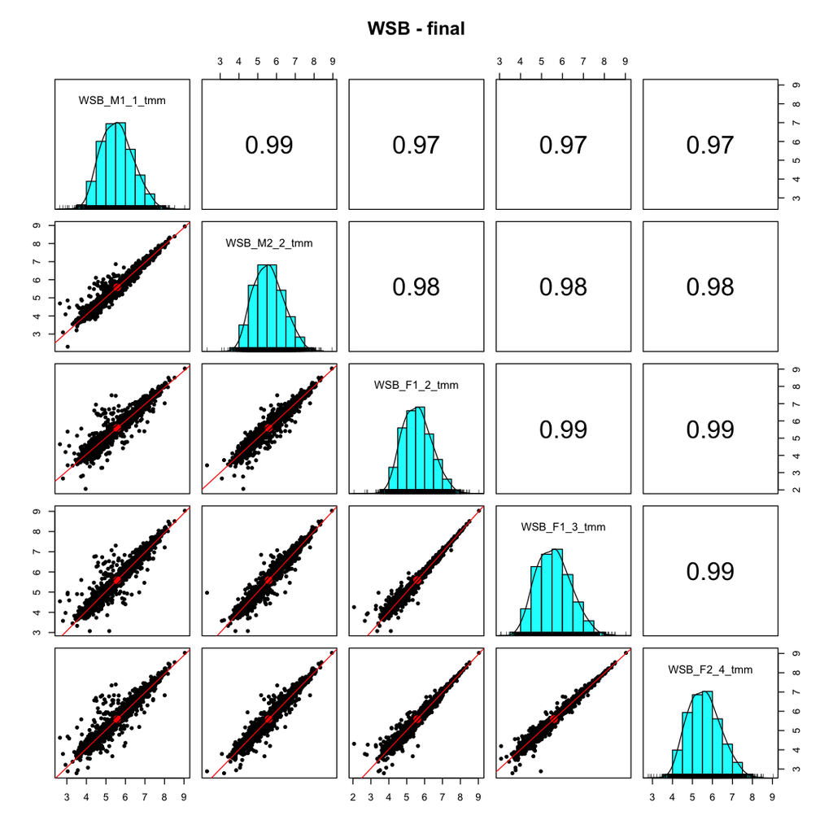

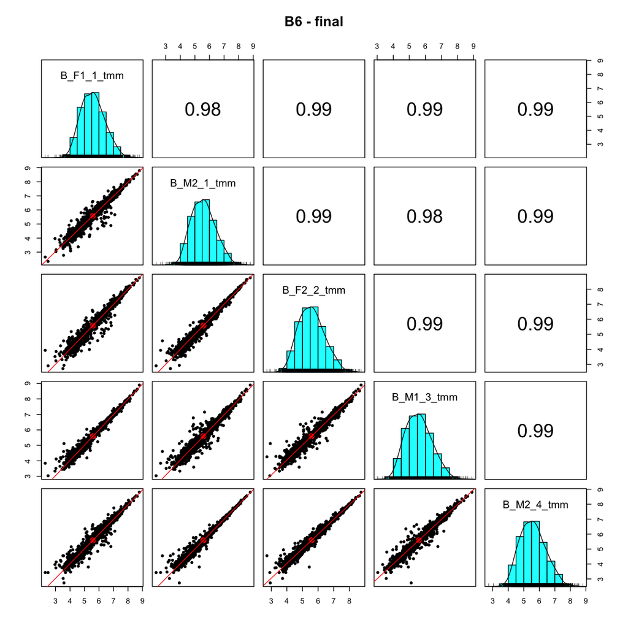

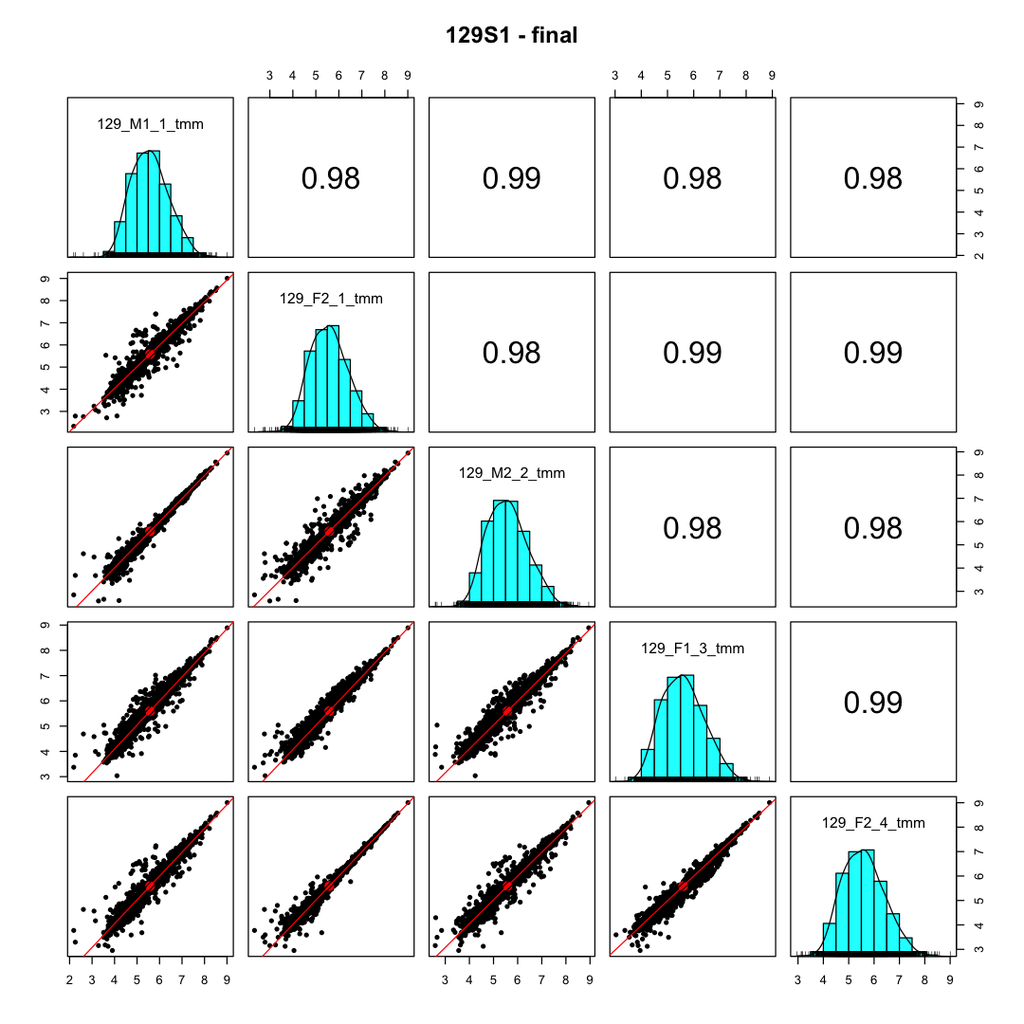

```r
# multi-panel scatter plot grids, final data
pairs.panels(log10(tmt_tmm[AJ]), lm = TRUE, main = "A/J - final")

pairs.panels(log10(tmt_tmm[NOD]), lm = TRUE, main = "NOD - final")

pairs.panels(log10(tmt_tmm[C]), lm = TRUE, main = "CAST - final")

pairs.panels(log10(tmt_tmm[P]), lm = TRUE, main = "PWK - final")

pairs.panels(log10(tmt_tmm[NZO]), lm = TRUE, main = "NZO - final")

pairs.panels(log10(tmt_tmm[WSB]), lm = TRUE, main = "WSB - final")

pairs.panels(log10(tmt_tmm[B]), lm = TRUE, main = "B6 - final")

pairs.panels(log10(tmt_tmm[S129]), lm = TRUE, main = "129S1 - final")
```

### Sample-to-sample correlations are okay

The scatter plots in each group show two things: that differences between males and females are notable, and that the duplicate samples in each group (not sure if they are strict technical replicates) have (generally) very tight scatter plots.

### Compare averages of each group to each other

We can get a little heads up on the statistical testing by comparing group averages to each other.

> NOTE: Correlation coefficients are not very informative in the scatter plot grids. The liver samples from the mice co-vary with protein relative abundance, so the coefficients are always close to 1.0. The (subjective) visual impression of degree of scatter is a more useful metric.

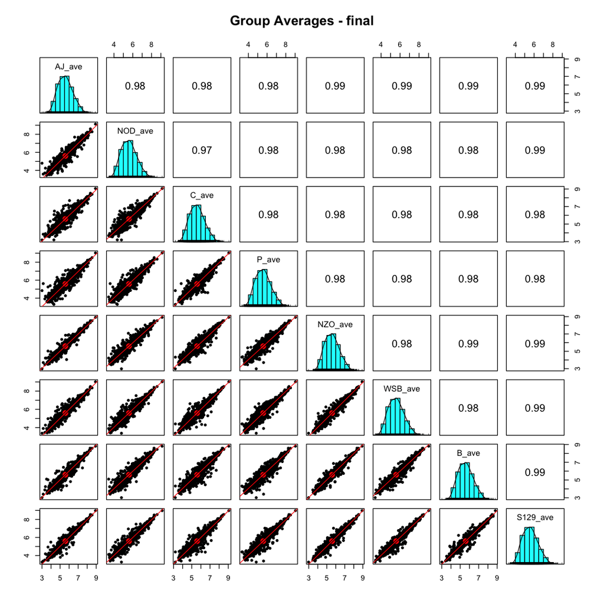

```r
# save the dataframe with the averages by developmental age
ave_tmm <- cbind(AJ_ave = rowMeans(tmt_tmm[AJ]),
                 NOD_ave = rowMeans(tmt_tmm[NOD]),
                 C_ave = rowMeans(tmt_tmm[C]),
                 P_ave = rowMeans(tmt_tmm[P]),
                 NZO_ave = rowMeans(tmt_tmm[NZO]),
                 WSB_ave = rowMeans(tmt_tmm[WSB]),
                 B_ave = rowMeans(tmt_tmm[B]),
                 S129_ave = rowMeans(tmt_tmm[S129]))

# make a scatter plot grid for the group averages
pairs.panels(log10(ave_tmm), lm = TRUE, main = "Group Averages - final")
```

## Summary

The degree of scatter between founder strain averages show that the strains have differences in liver relative protein abundances. Quality control checks seem okay. We can move on to any statistical testing.